# weather_classification

### Feature engineering

##### - finding the correlation

##### -getting the truth label for the dataset

##### -normalizing the dataset

```python
outliers_dict = {}

# Iterate through columns and process only numeric columns
for column in cleaned_df.columns:
    if pd.api.types.is_numeric_dtype(cleaned_df[column]):
        # Calculate quantiles for the numeric column
        Q1 = cleaned_df[column].quantile(0.25)
        Q3 = cleaned_df[column].quantile(0.75)
        IQR = Q3 - Q1

        # Identify outliers in the numeric column
        outliers = ((cleaned_df[column] < (Q1 - 1.5 * IQR)) | (cleaned_df[column] > (Q3 + 1.5 * IQR))).sum()

        outliers_dict[column] = outliers
print(outliers_dict)
```

[output not shown]

```python
from scipy.stats import mstats
# Define Winsorization limits
lower_limit = 0.005
upper_limit = 0.005

# Apply Winsorization to the DataFrame
cleaned_df_win = cleaned_df.copy()

for column in cleaned_df.columns:
    if column != 'time_1':  # Skip the datetime column
        cleaned_df_win[column] = mstats.winsorize(cleaned_df[column], limits=(lower_limit, upper_limit))

cleaned_df_win.head()
```

|  | time_1 | lat_long_1 | rtc | battery | solarpanel | command | solar | precipitation | strikes | avg_wind_speed | ... | particulateserr | particulatesvsn | peakspl | pm1 | pm10 | pm25 | temperature | vbatt | vpanel | month |
| --- | --- | --- | --- | --- | --- | --- | --- | --- | --- | --- | --- | --- | --- | --- | --- | --- | --- | --- | --- | --- | --- |
| 0 | 2021-05-14 18:11:23+00:00 | -37.8022141, 144.9656262 | 10090042.0 | 4.161 | 0.024 | 0.0 | 0.0 | 0.0 | 0.0 | 3.67 | ... | 0.0 | 151.0 | 69.0 | 12.0 | 19.0 | 17.0 | 12.3 | 3.96 | 0.00 | 5 |
| 1 | 2022-05-03 10:25:31+00:00 | -37.8022141, 144.9656262 | 17564045.0 | 4.181 | 0.000 | 0.0 | 0.0 | 0.0 | 0.0 | 0.54 | ... | 0.0 | 151.0 | 62.0 | 15.0 | 24.0 | 22.0 | 10.9 | 3.93 | 0.00 | 5 |
| 2 | 2022-05-03 21:42:23+00:00 | -37.8022141, 144.9656262 | 17604657.0 | 4.143 | 20.670 | 0.0 | 24.0 | 0.0 | 0.0 | 0.76 | ... | 0.0 | 151.0 | 64.0 | 0.0 | 0.0 | 0.0 | 15.1 | 3.76 | 16.33 | 5 |
| 3 | 2022-05-04 00:42:43+00:00 | -37.8022141, 144.9656262 | 17615477.0 | 4.208 | 20.694 | 0.0 | 68.0 | 0.0 | 0.0 | 1.01 | ... | 0.0 | 151.0 | 68.0 | 19.0 | 29.0 | 24.0 | 10.5 | 3.92 | 0.00 | 5 |
| 4 | 2021-05-15 07:55:22+00:00 | -37.8022141, 144.9656262 | 10139481.0 | 4.197 | 0.128 | 0.0 | 0.0 | 0.0 | 0.0 | 2.66 | ... | 0.0 | 151.0 | 62.0 | 0.0 | 0.0 | 0.0 | 14.9 | 4.01 | 18.33 | 5 |

5 rows × 31 columns

```python
cleaned_df_win.describe()
```

[output not shown]

|  | rtc | battery | solarpanel | command | solar | precipitation | strikes | avg_wind_speed | avg_wind_direction | gust_wind_speed | ... | particulateserr | particulatesvsn | peakspl | pm1 | pm10 | pm25 | temperature | vbatt | vpanel | month |
| --- | --- | --- | --- | --- | --- | --- | --- | --- | --- | --- | --- | --- | --- | --- | --- | --- | --- | --- | --- | --- | --- |
| count | 1.218770e+05 | 121877.000000 | 121877.000000 | 121877.0 | 121877.000000 | 121877.0 | 121877.0 | 121877.000000 | 121877.000000 | 121877.000000 | ... | 121877.0 | 121877.000000 | 121877.000000 | 121877.000000 | 121877.000000 | 121877.000000 | 121877.000000 | 121877.000000 | 121877.000000 | 121877.000000 |
| mean | 3.738096e+07 | 4.180267 | 10.494474 | 0.0 | 119.912436 | 0.0 | 0.0 | 1.105581 | 166.731478 | 3.056089 | ... | 0.0 | 146.821082 | 69.929216 | 3.065566 | 5.483225 | 4.372384 | 16.091607 | 3.862141 | 12.896810 | 6.370316 |
| std | 2.706590e+07 | 0.025032 | 10.078539 | 0.0 | 204.787344 | 0.0 | 0.0 | 0.573849 | 79.777133 | 1.817937 | ... | 0.0 | 24.769898 | 7.640141 | 5.676719 | 9.437103 | 8.083260 | 5.083094 | 0.096540 | 11.027589 | 3.399470 |
| min | 1.352000e+04 | 4.124000 | 0.000000 | 0.0 | 0.000000 | 0.0 | 0.0 | 0.000000 | 0.000000 | 0.000000 | ... | 0.0 | 0.000000 | 57.000000 | 0.000000 | 0.000000 | 0.000000 | 5.400000 | 3.490000 | 0.000000 | 1.000000 |
| 25% | 1.364448e+07 | 4.158000 | 0.032000 | 0.0 | 0.000000 | 0.0 | 0.0 | 0.710000 | 135.500000 | 1.730000 | ... | 0.0 | 151.000000 | 63.000000 | 0.000000 | 1.000000 | 0.000000 | 12.600000 | 3.810000 | 0.000000 | 3.000000 |
| 50% | 3.178422e+07 | 4.181000 | 11.604000 | 0.0 | 2.000000 | 0.0 | 0.0 | 0.980000 | 176.800000 | 2.640000 | ... | 0.0 | 151.000000 | 69.000000 | 1.000000 | 2.000000 | 1.000000 | 15.500000 | 3.860000 | 16.410000 | 6.000000 |
| 75% | 6.042885e+07 | 4.206000 | 21.411000 | 0.0 | 157.000000 | 0.0 | 0.0 | 1.350000 | 197.300000 | 3.890000 | ... | 0.0 | 151.000000 | 75.000000 | 3.000000 | 6.000000 | 4.000000 | 18.800000 | 3.930000 | 21.690000 | 9.000000 |
| max | 9.049698e+07 | 4.227000 | 22.886000 | 0.0 | 905.000000 | 0.0 | 0.0 | 3.670000 | 357.900000 | 10.520000 | ... | 0.0 | 151.000000 | 94.000000 | 31.000000 | 58.000000 | 47.000000 | 33.400000 | 4.020000 | 29.340000 | 12.000000 |

8 rows × 29 columns

```python
cleaned_df_win.head()
```

|  | time_1 | lat_long_1 | rtc | battery | solarpanel | command | solar | precipitation | strikes | avg_wind_speed | ... | particulateserr | particulatesvsn | peakspl | pm1 | pm10 | pm25 | temperature | vbatt | vpanel | month |
| --- | --- | --- | --- | --- | --- | --- | --- | --- | --- | --- | --- | --- | --- | --- | --- | --- | --- | --- | --- | --- | --- |
| 0 | 2021-05-14 18:11:23+00:00 | -37.8022141, 144.9656262 | 10090042.0 | 4.161 | 0.024 | 0.0 | 0.0 | 0.0 | 0.0 | 3.67 | ... | 0.0 | 151.0 | 69.0 | 12.0 | 19.0 | 17.0 | 12.3 | 3.96 | 0.00 | 5 |
| 1 | 2022-05-03 10:25:31+00:00 | -37.8022141, 144.9656262 | 17564045.0 | 4.181 | 0.000 | 0.0 | 0.0 | 0.0 | 0.0 | 0.54 | ... | 0.0 | 151.0 | 62.0 | 15.0 | 24.0 | 22.0 | 10.9 | 3.93 | 0.00 | 5 |
| 2 | 2022-05-03 21:42:23+00:00 | -37.8022141, 144.9656262 | 17604657.0 | 4.143 | 20.670 | 0.0 | 24.0 | 0.0 | 0.0 | 0.76 | ... | 0.0 | 151.0 | 64.0 | 0.0 | 0.0 | 0.0 | 15.1 | 3.76 | 16.33 | 5 |
| 3 | 2022-05-04 00:42:43+00:00 | -37.8022141, 144.9656262 | 17615477.0 | 4.208 | 20.694 | 0.0 | 68.0 | 0.0 | 0.0 | 1.01 | ... | 0.0 | 151.0 | 68.0 | 19.0 | 29.0 | 24.0 | 10.5 | 3.92 | 0.00 | 5 |
| 4 | 2021-05-15 07:55:22+00:00 | -37.8022141, 144.9656262 | 10139481.0 | 4.197 | 0.128 | 0.0 | 0.0 | 0.0 | 0.0 | 2.66 | ... | 0.0 | 151.0 | 62.0 | 0.0 | 0.0 | 0.0 | 14.9 | 4.01 | 18.33 | 5 |

5 rows × 31 columns

#### getting the correlation of the dataframe

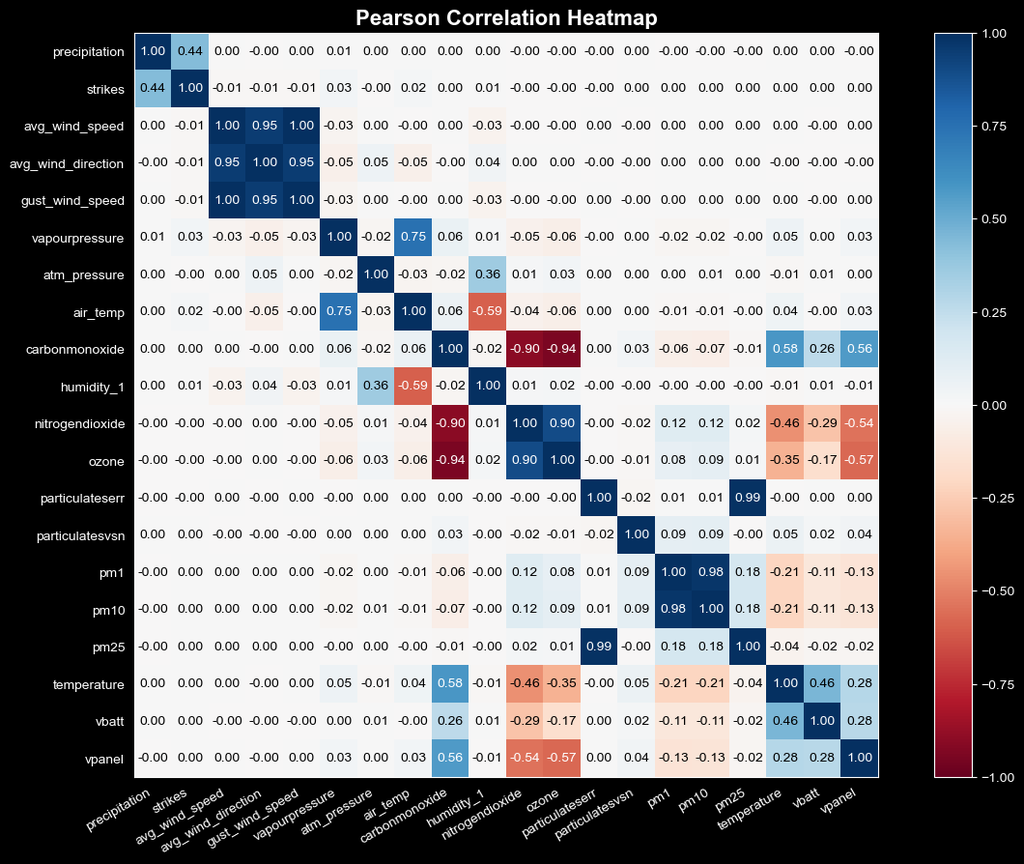

```python
def corrheatmap(R, labels):
    """
    Draws a correlation heat map, given:
    * R - matrix of correlation coefficients for all variable pairs,
    * labels - list of column names
    """
    assert R.shape[0] == R.shape[1] and R.shape[0] == len(labels)
    k = R.shape[0]

    # plot the heat map using a custom colour palette
    # (correlations are in [-1, 1])
    plt.imshow(R, cmap=plt.get_cmap("RdBu"), vmin=-1, vmax=1)

    # add text labels
    for i in range(k):
        for j in range(k):
            plt.text(j, i, f"{R[i, j]:.2f}", ha="center", va="center",
                     color="black" if np.abs(R[i, j]) < 0.5 else "white")

    plt.xticks(np.arange(k), labels=labels, rotation=30, ha='right')
    plt.tick_params(axis="x", which="both",
                    labelbottom=True, labeltop=False, bottom=False, top=False)

    plt.yticks(np.arange(k), labels=labels)
    plt.tick_params(axis="y", which="both",
                    labelleft=True, left=False, right=False)

    plt.grid(False)
    plt.colorbar()

# Specify columns to exclude
columns_to_exclude = ['time_1', 'lat_long_1', 'month', 'command', 'battery', 'peakspl',
                     'ibatt', 'averagespl','rtc','solar','solarpanel']  # replace with your column names

# Drop the specified columns
cleaned_df_reduced = cleaned_df.drop(columns=columns_to_exclude)

# Calculate the correlation matrix
correlation_matrix = cleaned_df_reduced.corr()

# Get the column labels
labels = correlation_matrix.columns

# Plot the correlation heatmap
plt.figure(figsize=(15, 10))
corrheatmap(correlation_matrix.values, labels)
plt.title('Pearson Correlation Heatmap', fontsize=16, fontweight='bold')
plt.show()
```

#### important columns needed

```python
cleaned_df_win.columns
```

```
Index(['time_1', 'lat_long_1', 'rtc', 'battery', 'solarpanel', 'command',
       'solar', 'precipitation', 'strikes', 'avg_wind_speed',
       'avg_wind_direction', 'gust_wind_speed', 'vapourpressure',
       'atm_pressure', 'air_temp', 'averagespl', 'carbonmonoxide',
       'humidity_1', 'ibatt', 'nitrogendioxide', 'ozone', 'particulateserr',
       'particulatesvsn', 'peakspl', 'pm1', 'pm10', 'pm25', 'temperature',
       'vbatt', 'vpanel', 'month'],
      dtype='object')
```

```python
final_df = cleaned_df_win[['time_1', 'lat_long_1', 'precipitation', 'strikes', 'avg_wind_speed',
       'avg_wind_direction', 'gust_wind_speed', 'vapourpressure',
       'atm_pressure', 'air_temp', 'carbonmonoxide',
       'humidity_1', 'nitrogendioxide', 'ozone', 'particulateserr',
       'particulatesvsn', 'pm1', 'pm10', 'pm25', 'temperature']]
final_df['ozone'] = final_df['ozone'].apply(lambda x: max(x, 0))
```

```python
final_df.head()
```

|  | time_1 | lat_long_1 | precipitation | strikes | avg_wind_speed | avg_wind_direction | gust_wind_speed | vapourpressure | atm_pressure | air_temp | carbonmonoxide | humidity_1 | nitrogendioxide | ozone | particulateserr | particulatesvsn | pm1 | pm10 | pm25 | temperature |
| --- | --- | --- | --- | --- | --- | --- | --- | --- | --- | --- | --- | --- | --- | --- | --- | --- | --- | --- | --- | --- |
| 0 | 2021-05-14 18:11:23+00:00 | -37.8022141, 144.9656262 | 0.0 | 0.0 | 3.67 | 253.5 | 10.52 | 0.93 | 100.70 | 7.8 | -6448.0 | 88.0 | 287.0 | 137.0 | 0.0 | 151.0 | 12.0 | 19.0 | 17.0 | 12.3 |
| 1 | 2022-05-03 10:25:31+00:00 | -37.8022141, 144.9656262 | 0.0 | 0.0 | 0.54 | 158.5 | 1.14 | 1.25 | 100.91 | 16.2 | -6916.0 | 68.0 | 325.0 | 156.0 | 0.0 | 151.0 | 15.0 | 24.0 | 22.0 | 10.9 |
| 2 | 2022-05-03 21:42:23+00:00 | -37.8022141, 144.9656262 | 0.0 | 0.0 | 0.76 | 7.7 | 2.43 | 1.21 | 100.83 | 14.0 | -6261.0 | 75.0 | 268.0 | 137.0 | 0.0 | 151.0 | 0.0 | 0.0 | 0.0 | 15.1 |
| 3 | 2022-05-04 00:42:43+00:00 | -37.8022141, 144.9656262 | 0.0 | 0.0 | 1.01 | 9.9 | 3.22 | 1.17 | 100.91 | 13.4 | -6916.0 | 76.0 | 325.0 | 156.0 | 0.0 | 151.0 | 19.0 | 29.0 | 24.0 | 10.5 |
| 4 | 2021-05-15 07:55:22+00:00 | -37.8022141, 144.9656262 | 0.0 | 0.0 | 2.66 | 253.8 | 8.07 | 0.78 | 101.63 | 11.7 | -6261.0 | 56.0 | 258.0 | 119.0 | 0.0 | 151.0 | 0.0 | 0.0 | 0.0 | 14.9 |

```python
final_df.describe()
```

|  | precipitation | strikes | avg_wind_speed | avg_wind_direction | gust_wind_speed | vapourpressure | atm_pressure | air_temp | carbonmonoxide | humidity_1 | nitrogendioxide | ozone | particulateserr | particulatesvsn | pm1 | pm10 | pm25 | temperature |
| --- | --- | --- | --- | --- | --- | --- | --- | --- | --- | --- | --- | --- | --- | --- | --- | --- | --- | --- |
| count | 121877.0 | 121877.0 | 121877.000000 | 121877.000000 | 121877.000000 | 121877.000000 | 121877.000000 | 121877.000000 | 121877.000000 | 121877.000000 | 121877.000000 | 121877.000000 | 121877.0 | 121877.000000 | 121877.000000 | 121877.000000 | 121877.000000 | 121877.000000 |
| mean | 0.0 | 0.0 | 1.105581 | 166.731478 | 3.056089 | 1.278932 | 101.177770 | 15.260613 | -4646.084872 | 73.284877 | 204.027241 | 81.641877 | 0.0 | 146.821082 | 3.065566 | 5.483225 | 4.372384 | 16.091607 |
| std | 0.0 | 0.0 | 0.573849 | 79.777133 | 1.817937 | 0.331538 | 0.785664 | 5.166684 | 1990.038163 | 14.210564 | 103.408029 | 66.642169 | 0.0 | 24.769898 | 5.676719 | 9.437103 | 8.083260 | 5.083094 |
| min | 0.0 | 0.0 | 0.000000 | 0.000000 | 0.000000 | 0.730000 | 98.360000 | 4.400000 | -8320.000000 | 20.000000 | -68.000000 | 0.000000 | 0.0 | 0.000000 | 0.000000 | 0.000000 | 0.000000 | 5.400000 |
| 25% | 0.0 | 0.0 | 0.710000 | 135.500000 | 1.730000 | 1.030000 | 100.710000 | 11.700000 | -6355.000000 | 65.000000 | 123.000000 | 0.000000 | 0.0 | 151.000000 | 0.000000 | 1.000000 | 0.000000 | 12.600000 |
| 50% | 0.0 | 0.0 | 0.980000 | 176.800000 | 2.640000 | 1.210000 | 101.200000 | 14.600000 | -4857.000000 | 76.000000 | 200.000000 | 91.000000 | 0.0 | 151.000000 | 1.000000 | 2.000000 | 1.000000 | 15.500000 |
| 75% | 0.0 | 0.0 | 1.350000 | 197.300000 | 3.890000 | 1.470000 | 101.710000 | 18.100000 | -2802.000000 | 84.000000 | 287.000000 | 137.000000 | 0.0 | 151.000000 | 3.000000 | 6.000000 | 4.000000 | 18.800000 |
| max | 0.0 | 0.0 | 3.670000 | 357.900000 | 10.520000 | 2.310000 | 102.990000 | 33.000000 | 1036.000000 | 97.000000 | 441.000000 | 211.000000 | 0.0 | 151.000000 | 31.000000 | 58.000000 | 47.000000 | 33.400000 |

#### creating a threshold for the Truth_label

```python
def classify_weather(row):
    # Define thresholds based on typical values for sunny weather
    if (#row['atm_pressure'] > 101.2 and  # Above average atmospheric pressure
        row['humidity_1'] < 40 and  # Lower humidity
        row['temperature'] > 23):  # Higher temperature
        return 'sunny'

    # Define thresholds for rainy weather
    elif (#row['atm_pressure'] < 100.7 and  # Below average atmospheric pressure
          row['humidity_1'] >= 70 and  # Higher humidity
          row['temperature'] <= 21):  # Lower temperature
        return 'rainy'

    # Define thresholds for cloudy weather
    elif (#100.7 < row['atm_pressure'] < 101.2 and  # Intermediate atmospheric pressure
          30 < row['humidity_1'] < 75 and  # Intermediate humidity
          14 < row['temperature'] < 22):  # Intermediate temperature
        return 'cloudy'

    # Define thresholds for stormy weather
    elif (#row['atm_pressure'] < 100.0 and  # Very low atmospheric pressure
          row['humidity_1'] > 85 and  # Very high humidity
          row['temperature'] > 20):  # Variable temperature
        return 'stormy'

    # Default case if no specific condition is met
    return 'sunny'

final_df['status'] = final_df.apply(classify_weather, axis=1)
final_df.head()
```

|  | time_1 | lat_long_1 | precipitation | strikes | avg_wind_speed | avg_wind_direction | gust_wind_speed | vapourpressure | atm_pressure | air_temp | ... | humidity_1 | nitrogendioxide | ozone | particulateserr | particulatesvsn | pm1 | pm10 | pm25 | temperature | status |
| --- | --- | --- | --- | --- | --- | --- | --- | --- | --- | --- | --- | --- | --- | --- | --- | --- | --- | --- | --- | --- | --- |
| 0 | 2021-05-14 18:11:23+00:00 | -37.8022141, 144.9656262 | 0.0 | 0.0 | 3.67 | 253.5 | 10.52 | 0.93 | 100.70 | 7.8 | ... | 88.0 | 287.0 | 137.0 | 0.0 | 151.0 | 12.0 | 19.0 | 17.0 | 12.3 | rainy |
| 1 | 2022-05-03 10:25:31+00:00 | -37.8022141, 144.9656262 | 0.0 | 0.0 | 0.54 | 158.5 | 1.14 | 1.25 | 100.91 | 16.2 | ... | 68.0 | 325.0 | 156.0 | 0.0 | 151.0 | 15.0 | 24.0 | 22.0 | 10.9 | sunny |
| 2 | 2022-05-03 21:42:23+00:00 | -37.8022141, 144.9656262 | 0.0 | 0.0 | 0.76 | 7.7 | 2.43 | 1.21 | 100.83 | 14.0 | ... | 75.0 | 268.0 | 137.0 | 0.0 | 151.0 | 0.0 | 0.0 | 0.0 | 15.1 | rainy |
| 3 | 2022-05-04 00:42:43+00:00 | -37.8022141, 144.9656262 | 0.0 | 0.0 | 1.01 | 9.9 | 3.22 | 1.17 | 100.91 | 13.4 | ... | 76.0 | 325.0 | 156.0 | 0.0 | 151.0 | 19.0 | 29.0 | 24.0 | 10.5 | rainy |
| 4 | 2021-05-15 07:55:22+00:00 | -37.8022141, 144.9656262 | 0.0 | 0.0 | 2.66 | 253.8 | 8.07 | 0.78 | 101.63 | 11.7 | ... | 56.0 | 258.0 | 119.0 | 0.0 | 151.0 | 0.0 | 0.0 | 0.0 | 14.9 | cloudy |

5 rows × 21 columns

```python
final_df['status'].value_counts()
```

```
status
rainy     68689
sunny     28149
cloudy    21551
stormy     3488
Name: count, dtype: int64
```

#### Getting The percentage for each target label and visualizing it

```python
label_distribution = final_df['status'].value_counts()
total_samples = final_df['status'].count()
label_percentage = (label_distribution/total_samples)*100
print(label_percentage)
```

```
status
rainy     56.359280
sunny     23.096236
cloudy    17.682582
stormy     2.861902
Name: count, dtype: float64
```

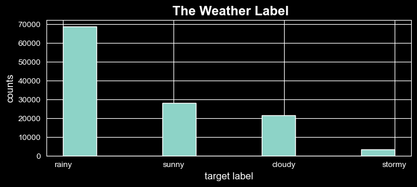

```python
plt.figure(figsize=(8,3))
final_df['status'].hist()
plt.title(' The Weather Label',fontsize=16, fontweight='bold', color='white')
plt.xlabel('target label', fontsize=12, color='white')
plt.ylabel('counts', fontsize=12, color='white')
```

This imbalance in the weather labels suggests that rainy weather dominates the dataset, and it’s important to consider this when building models, as the imbalance may affect the model's ability to predict less frequent weather conditions like sunny or stormy days. Getting the percentage of each label can help better understand the extent of this imbalance.

#### Normalizing the dataset without the target label

```python
# Drop the non-numeric columns
norm_column = final_df.iloc[:, 2:-1]
scaler = MinMaxScaler()

norm_column_scaled = scaler.fit_transform(norm_column)

# Convert the normalized data back to a DataFrame with original column names
norm_column_scaled = pd.DataFrame(norm_column_scaled, columns=norm_column.columns)

norm_column_scaled.head()
```

|  | precipitation | strikes | avg_wind_speed | avg_wind_direction | gust_wind_speed | vapourpressure | atm_pressure | air_temp | carbonmonoxide | humidity_1 | nitrogendioxide | ozone | particulateserr | particulatesvsn | pm1 | pm10 | pm25 | temperature |
| --- | --- | --- | --- | --- | --- | --- | --- | --- | --- | --- | --- | --- | --- | --- | --- | --- | --- | --- |
| 0 | 0.0 | 0.0 | 1.000000 | 0.708298 | 1.000000 | 0.126582 | 0.505400 | 0.118881 | 0.200086 | 0.883117 | 0.697446 | 0.649289 | 0.0 | 1.0 | 0.387097 | 0.327586 | 0.361702 | 0.246429 |
| 1 | 0.0 | 0.0 | 0.147139 | 0.442861 | 0.108365 | 0.329114 | 0.550756 | 0.412587 | 0.150064 | 0.623377 | 0.772102 | 0.739336 | 0.0 | 1.0 | 0.483871 | 0.413793 | 0.468085 | 0.196429 |
| 2 | 0.0 | 0.0 | 0.207084 | 0.021514 | 0.230989 | 0.303797 | 0.533477 | 0.335664 | 0.220073 | 0.714286 | 0.660118 | 0.649289 | 0.0 | 1.0 | 0.000000 | 0.000000 | 0.000000 | 0.346429 |
| 3 | 0.0 | 0.0 | 0.275204 | 0.027661 | 0.306084 | 0.278481 | 0.550756 | 0.314685 | 0.150064 | 0.727273 | 0.772102 | 0.739336 | 0.0 | 1.0 | 0.612903 | 0.500000 | 0.510638 | 0.182143 |
| 4 | 0.0 | 0.0 | 0.724796 | 0.709137 | 0.767110 | 0.031646 | 0.706263 | 0.255245 | 0.220073 | 0.467532 | 0.640472 | 0.563981 | 0.0 | 1.0 | 0.000000 | 0.000000 | 0.000000 | 0.339286 |

##########To be continued------------------

### features selection

```python
first_column = final_df.iloc[:,0]
last_column = final_df.iloc[:,-1]
first_column.head()
```

```
0   2021-05-14 18:11:23+00:00
1   2022-05-03 10:25:31+00:00
2   2022-05-03 21:42:23+00:00
3   2022-05-04 00:42:43+00:00
4   2021-05-15 07:55:22+00:00
Name: time_1, dtype: datetime64[ns, UTC]
```

```python
#combining my features needed for my model
feat_df = pd.concat([first_column, norm_column_scaled, last_column], axis=1)
feat_df.head()
```

|  | time_1 | precipitation | strikes | avg_wind_speed | avg_wind_direction | gust_wind_speed | vapourpressure | atm_pressure | air_temp | carbonmonoxide | humidity_1 | nitrogendioxide | ozone | particulateserr | particulatesvsn | pm1 | pm10 | pm25 | temperature | status |
| --- | --- | --- | --- | --- | --- | --- | --- | --- | --- | --- | --- | --- | --- | --- | --- | --- | --- | --- | --- | --- |
| 0 | 2021-05-14 18:11:23+00:00 | 0.0 | 0.0 | 1.000000 | 0.708298 | 1.000000 | 0.126582 | 0.505400 | 0.118881 | 0.200086 | 0.883117 | 0.697446 | 0.649289 | 0.0 | 1.0 | 0.387097 | 0.327586 | 0.361702 | 0.246429 | rainy |
| 1 | 2022-05-03 10:25:31+00:00 | 0.0 | 0.0 | 0.147139 | 0.442861 | 0.108365 | 0.329114 | 0.550756 | 0.412587 | 0.150064 | 0.623377 | 0.772102 | 0.739336 | 0.0 | 1.0 | 0.483871 | 0.413793 | 0.468085 | 0.196429 | sunny |
| 2 | 2022-05-03 21:42:23+00:00 | 0.0 | 0.0 | 0.207084 | 0.021514 | 0.230989 | 0.303797 | 0.533477 | 0.335664 | 0.220073 | 0.714286 | 0.660118 | 0.649289 | 0.0 | 1.0 | 0.000000 | 0.000000 | 0.000000 | 0.346429 | rainy |
| 3 | 2022-05-04 00:42:43+00:00 | 0.0 | 0.0 | 0.275204 | 0.027661 | 0.306084 | 0.278481 | 0.550756 | 0.314685 | 0.150064 | 0.727273 | 0.772102 | 0.739336 | 0.0 | 1.0 | 0.612903 | 0.500000 | 0.510638 | 0.182143 | rainy |
| 4 | 2021-05-15 07:55:22+00:00 | 0.0 | 0.0 | 0.724796 | 0.709137 | 0.767110 | 0.031646 | 0.706263 | 0.255245 | 0.220073 | 0.467532 | 0.640472 | 0.563981 | 0.0 | 1.0 | 0.000000 | 0.000000 | 0.000000 | 0.339286 | cloudy |

#### encoding my truth_label

```python
from sklearn.preprocessing import LabelEncoder

# Select the last column
last_column = feat_df.columns[-1]

# Initialize LabelEncoder
label_encoder = LabelEncoder()

# Fit and transform the last column, and add the encoded values as a new column
feat_df[last_column + '_encoded'] = label_encoder.fit_transform(feat_df[last_column])
feat_df.head()
```

|  | time_1 | precipitation | strikes | avg_wind_speed | avg_wind_direction | gust_wind_speed | vapourpressure | atm_pressure | air_temp | carbonmonoxide | ... | nitrogendioxide | ozone | particulateserr | particulatesvsn | pm1 | pm10 | pm25 | temperature | status | status_encoded |
| --- | --- | --- | --- | --- | --- | --- | --- | --- | --- | --- | --- | --- | --- | --- | --- | --- | --- | --- | --- | --- | --- |
| 0 | 2021-05-14 18:11:23+00:00 | 0.0 | 0.0 | 1.000000 | 0.708298 | 1.000000 | 0.126582 | 0.505400 | 0.118881 | 0.200086 | ... | 0.697446 | 0.649289 | 0.0 | 1.0 | 0.387097 | 0.327586 | 0.361702 | 0.246429 | rainy | 1 |
| 1 | 2022-05-03 10:25:31+00:00 | 0.0 | 0.0 | 0.147139 | 0.442861 | 0.108365 | 0.329114 | 0.550756 | 0.412587 | 0.150064 | ... | 0.772102 | 0.739336 | 0.0 | 1.0 | 0.483871 | 0.413793 | 0.468085 | 0.196429 | sunny | 3 |
| 2 | 2022-05-03 21:42:23+00:00 | 0.0 | 0.0 | 0.207084 | 0.021514 | 0.230989 | 0.303797 | 0.533477 | 0.335664 | 0.220073 | ... | 0.660118 | 0.649289 | 0.0 | 1.0 | 0.000000 | 0.000000 | 0.000000 | 0.346429 | rainy | 1 |
| 3 | 2022-05-04 00:42:43+00:00 | 0.0 | 0.0 | 0.275204 | 0.027661 | 0.306084 | 0.278481 | 0.550756 | 0.314685 | 0.150064 | ... | 0.772102 | 0.739336 | 0.0 | 1.0 | 0.612903 | 0.500000 | 0.510638 | 0.182143 | rainy | 1 |
| 4 | 2021-05-15 07:55:22+00:00 | 0.0 | 0.0 | 0.724796 | 0.709137 | 0.767110 | 0.031646 | 0.706263 | 0.255245 | 0.220073 | ... | 0.640472 | 0.563981 | 0.0 | 1.0 | 0.000000 | 0.000000 | 0.000000 | 0.339286 | cloudy | 0 |

5 rows × 21 columns

#### using RandomForestRegressor to determine the features that contributed to high rate of Ozone

```python
X = feat_df.drop(columns=['time_1','status', 'ozone','status_encoded'])
Y = feat_df['ozone']
```

```python
X_train, X_test, Y_train, Y_test = train_test_split(X,Y, test_size= 0.3, random_state = 42)
```

```python
print(X_train.shape)
print(Y_train.shape)
print(X_test.shape)
```

```
(85313, 17)
(85313,)
(36564, 17)
```

```python
from sklearn.ensemble import RandomForestRegressor

model = RandomForestRegressor(n_estimators = 100, random_state= 42)

net = model.fit(X_train, Y_train)
```

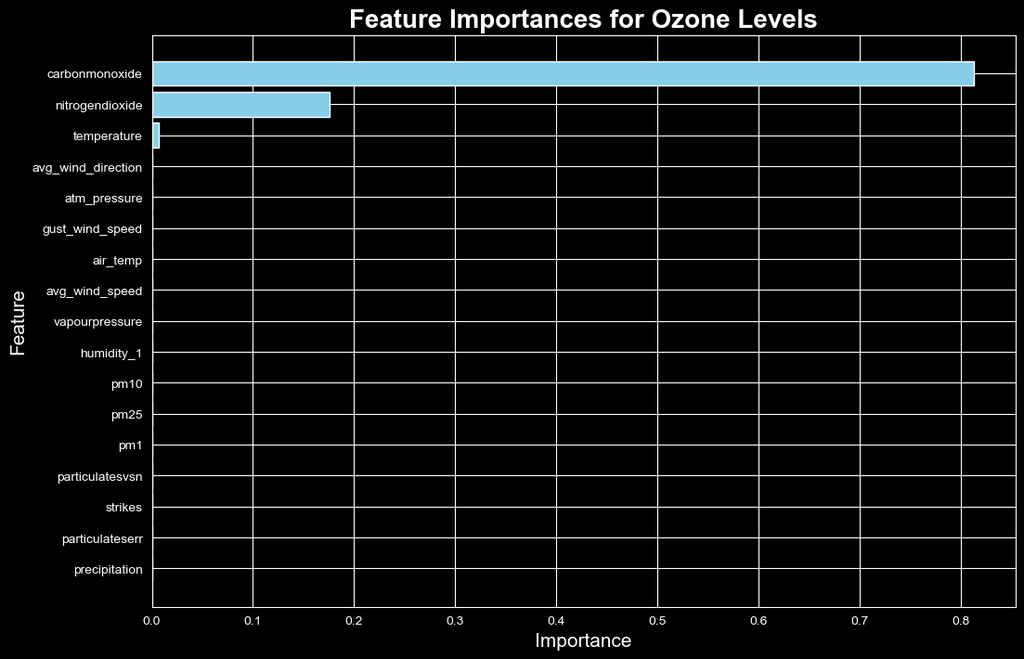

```python
#get features importance
importance = model.feature_importances_
feature_names = X.columns
#Create a DataFrame for visualization
importance_df = pd.DataFrame({'Feature': feature_names, 'Importance': importance})
importance_df = importance_df.sort_values(by='Importance', ascending=False)

# Plot feature importances
import matplotlib.pyplot as plt

plt.figure(figsize=(12, 8))
plt.barh(importance_df['Feature'], importance_df['Importance'], color='skyblue')
plt.xlabel('Importance', fontsize=15)
plt.ylabel('Feature', fontsize=15)
plt.title('Feature Importances for Ozone Levels', fontsize=20, fontweight='bold')
plt.gca().invert_yaxis()
plt.style.use('dark_background')
plt.show()
```

The feature importance plot from the RandomForestRegressor shows that carbon monoxide and nitrogen dioxide are the biggest factors affecting ozone levels. Carbon monoxide has the highest impact, meaning it has a strong connection to ozone, likely because of its role in chemical reactions in the air. Nitrogen dioxide also significantly affects ozone, especially in places with heavy traffic emissions. Other factors like temperature have a smaller effect. This suggests that controlling carbon monoxide and nitrogen dioxide emissions is key to managing ozone levels effectively.

```python
x = feat_df.drop(columns=['time_1', 'status','status_encoded'])
y = feat_df['status_encoded']
```

[figure not shown]

```python
from sklearn.manifold import TSNE

# Apply t-SNE
#tsne = TSNE(n_components=2, random_state=42)
#X_tsne = tsne.fit_transform(X_scaled)

tsne = TSNE(n_components =2, random_state= 42)
X_tsne = tsne.fit_transform(x)

# Plotting the t-SNE results
plt.figure(figsize=(8, 6))
scatter = plt.scatter(X_tsne[:, 0], X_tsne[:, 1], c=y, cmap='viridis')

# Adding a legend with labels
unique_labels = list(feat_df['status_encoded'].unique())
plt.legend(handles=scatter.legend_elements()[0], labels=unique_labels)
plt.title('t-SNE Visualization of Iris Dataset')
plt.xlabel('t-SNE Component 1')
plt.ylabel('t-SNE Component 2')
plt.show()
```

.In this plot, we can see that the data points, represented by different colors for each class, are spread out and overlap in some areas rather than forming clear, separate clusters.This overlapping indicates that the data might not be easily separable using a simple linear boundary, suggesting that a non-linear model might be more effective for classification tasks on this dataset.

#### Balancing the label using Resampling Technique by using combination of sampling called smote

```python
x = feat_df.drop(columns=['time_1', 'status','status_encoded'])
y = feat_df['status_encoded']
```

```python
#applying smote
smote = SMOTE(random_state = 42)

x_smote, y_smote = smote.fit_resample(x, y)
```

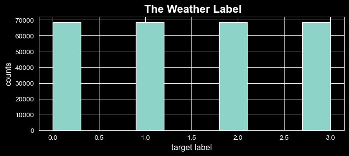

```python
plt.figure(figsize=(8,3))
y_smote.hist()
plt.title(' The Weather Label',fontsize=16, fontweight='bold', color='white')
plt.xlabel('target label', fontsize=12, color='white')
plt.ylabel('counts', fontsize=12, color='white')
```

This balanced distribution suggests that the dataset is now suitable for training machine learning models without being biased toward any particular weather condition.

#### dataset splitting for model training

```python
#split data for training

x_train, x_test, y_train, y_test = train_test_split(x_smote, y_smote, test_size=0.2, random_state=42)
```

```python
print(x_train.shape)
print(x_test.shape)
print(y_train.shape)
print(y_test.shape)
```

```
(219804, 18)
(54952, 18)
(219804,)
(54952,)
```

#### using a Logistic Regression

```python
from sklearn.model_selection import cross_val_score, StratifiedKFold

#intialize logistic regresiom
log_reg = LogisticRegression(penalty = 'l1', solver='liblinear', C=0.2)

#cross_validation
#cv = StratifiedKFold(n_splits =5, shuffle = True, random_state = 42)

#perform cross val
scores = cross_val_score(log_reg, x_train, y_train, cv=5, scoring='accuracy')

#scores = cross_val_score(log_reg, x, y, cv=cv, scoring='accuracy')
print(f'Cross-validated accuracy scores: {scores}')
print(f'Average accuracy: {scores.mean():.2f}')

log_reg.fit(x_train, y_train)

#evaluation
training_accuracy = log_reg.score(x_train,y_train)
testing_accuracy = log_reg.score(x_test, y_test)

print(f"training_accuracy : {training_accuracy}")
print(f"testing_accuracy : {testing_accuracy}")
```

```
Cross-validated accuracy scores: [0.75669343 0.75632947 0.75603376 0.75569255 0.75459509]
Average accuracy: 0.76
training_accuracy : 0.7560735928372551
testing_accuracy : 0.7552409375454943
```

[figure not shown]

```python
# Cross-validated accuracy scores and mean accuracy for Logistic Regression
scores_log_reg = [0.75065131, 0.74761187, 0.75005713, 0.74957722, 0.74898304]
mean_accuracy_log_reg = np.mean(scores_log_reg)

# Training and testing accuracy for Logistic Regression
training_accuracy_log_reg = 0.7493029845971022
testing_accuracy_log_reg = 0.7476690189769278

# Plotting the accuracies for Logistic Regression without grid lines
plt.figure(figsize=(8, 4))
plt.plot(range(1, 6), scores_log_reg, marker='o', linestyle='-', color='skyblue', label='Cross-validated Accuracy')
plt.axhline(y=training_accuracy_log_reg, color='g', linestyle='-', label=f'Training Accuracy: {training_accuracy_log_reg:.2f}')
plt.axhline(y=testing_accuracy_log_reg, color='b', linestyle='-', label=f'Testing Accuracy: {testing_accuracy_log_reg:.2f}')
plt.title('Logistic Regression Classifier Accuracy')
plt.xlabel('Fold')
plt.ylabel('Accuracy')
plt.legend(loc='best')
plt.grid(False)  # Disable grid lines
plt.show()
```

The graph shows the accuracy of a Logistic Regression model using cross-validation, along with the training and testing accuracy. The cross-validation accuracy fluctuates slightly across the five folds but generally stays around 0.75, meaning the model predicts correctly about 75% of the time. Both the training and testing accuracy are also around 75%, which suggests the model is performing consistently and is neither overfitting nor underfitting. The small differences between the cross-validation scores indicate that the model's performance is stable across different subsets of the data.

#### Using support Vector Machine

```python
x_train_svm, x_test_svm, y_train_svm, y_test_svm= train_test_split(x_smote, y_smote, test_size=0.2, random_state=42)

svm_clf = SVC(kernel = 'rbf', C= 0.2, gamma='scale', random_state = 42) #using rbf because is non-linear

scores_svm = cross_val_score(svm_clf, x_train_svm, y_train_svm, cv=5, scoring= 'accuracy')
print(f'Cross-validated accuracy scores: {scores_svm}')
print(f'Average accuracy: {scores_svm.mean():.2f}')

#fitting svm
svm_clf.fit(x_train_svm, y_train_svm)

training_accuracy_svm = svm_clf.score(x_train_svm,y_train_svm)
testing_accuracy_svm = svm_clf.score(x_test_svm, y_test_svm)

print(f"training_accuracy : {training_accuracy_svm}")
print(f"testing_accuracy : {testing_accuracy_svm}")
```

```
Cross-validated accuracy scores: [0.94292669 0.94424604 0.94531517 0.94399581 0.94324386]
Average accuracy: 0.94
training_accuracy : 0.9488316864115303
testing_accuracy : 0.9479181831416509
```

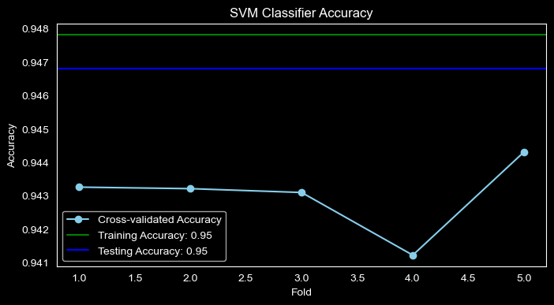

```python
# Cross-validated accuracy scores and mean accuracy for SVM
scores_svm = [0.94325609, 0.94321038, 0.94309612, 0.94122218, 0.94430733]
mean_accuracy_svm = np.mean(scores_svm)

# Training and testing accuracy for SVM
training_accuracy_svm = 0.9478221125279949
testing_accuracy_svm = 0.9467987860616476

# Plotting the accuracies for SVM without grid lines
plt.figure(figsize=(8, 4))
plt.plot(range(1, 6), scores_svm, marker='o', linestyle='-', color='skyblue', label='Cross-validated Accuracy')
plt.axhline(y=training_accuracy_svm, color='g', linestyle='-', label=f'Training Accuracy: {training_accuracy_svm:.2f}')
plt.axhline(y=testing_accuracy_svm, color='b', linestyle='-', label=f'Testing Accuracy: {testing_accuracy_svm:.2f}')
plt.title('SVM Classifier Accuracy')
plt.xlabel('Fold')
plt.ylabel('Accuracy')
plt.legend(loc='best')
plt.grid(False)  # Disable grid lines
plt.show()
```

This graph shows the accuracy of an SVM (Support Vector Machine) classifier. The cross-validated accuracy is consistent across the five folds, staying around 94.3%. The training and testing accuracy are both around 95%, which means the model is performing very well and is making correct predictions most of the time. The small difference between cross-validation, training, and testing accuracy indicates that the model is stable and is neither overfitting nor underfitting the data. Overall, the SVM classifier is showing high accuracy and good reliability across different parts of the data.

#### using Decission Tree

```python
x_train_dt, x_test_dt, y_train_dt, y_test_dt= train_test_split(x_smote, y_smote, test_size=0.42,random_state=42)

dt_clf = DecisionTreeClassifier(max_depth = 2, class_weight='balanced', criterion='gini',random_state=42)

score_dt = cross_val_score(dt_clf, x_train_dt, y_train_dt, cv=5,scoring='accuracy')

print(f'cross-validated accuracy scores: {score_dt}')
print(f'Average accuracy: {score_dt.mean():.2f}')

#fiiting decission tree
dt_clf.fit(x_train_dt, y_train_dt)

training_accuracy_dt = dt_clf.score(x_train_dt, y_train_dt)
testing_accuracy_dt = dt_clf.score(x_test_dt, y_test_dt)

print(f"training_accuracy : {training_accuracy_dt}")
print(f"testing_accuracy : {testing_accuracy_dt}")
```

```
cross-validated accuracy scores: [0.8762864  0.87848268 0.87716491 0.8780396  0.87760033]
Average accuracy: 0.88
training_accuracy : 0.8775210532260697
testing_accuracy : 0.8782127939825647
```

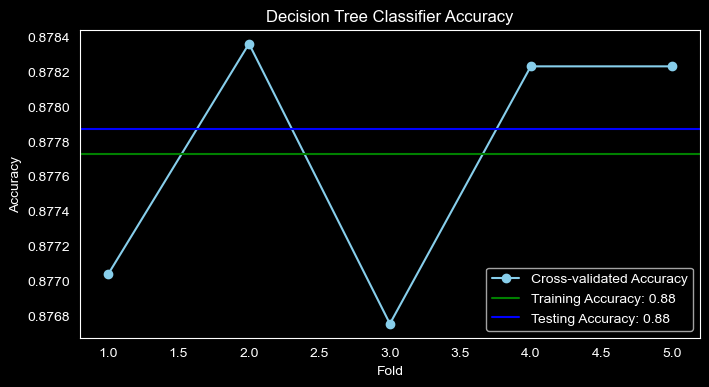

```python
# Cross-validated accuracy scores and mean accuracy for Decision Tree
score_dt = [0.87703704, 0.87836091, 0.87675335, 0.87823099, 0.87823099]
mean_accuracy_dt = np.mean(score_dt)

# Training and testing accuracy for Decision Tree
training_accuracy_dt = 0.8777289548173972
testing_accuracy_dt = 0.8778740260305576

# Plotting the accuracies for Decision Tree without grid lines
plt.figure(figsize=(8, 4))
plt.plot(range(1, 6), score_dt, marker='o', linestyle='-', color='skyblue', label='Cross-validated Accuracy')
plt.axhline(y=training_accuracy_dt, color='g', linestyle='-', label=f'Training Accuracy: {training_accuracy_dt:.2f}')
plt.axhline(y=testing_accuracy_dt, color='b', linestyle='-', label=f'Testing Accuracy: {testing_accuracy_dt:.2f}')
plt.title('Decision Tree Classifier Accuracy')
plt.xlabel('Fold')
plt.ylabel('Accuracy')
plt.legend(loc='best')
plt.grid(False)
plt.show()
```

This graph displays the accuracy of a Decision Tree Classifier. The cross-validation accuracy fluctuates slightly across the five folds, ranging between 87.7% and 87.8%. Both the training and testing accuracy are around 88%, which indicates that the model is performing well and is able to make accurate predictions. The minimal difference between cross-validation, training, and testing accuracy suggests that the model is balanced, without signs of overfitting or underfitting. Overall, the Decision Tree classifier is providing a stable performance with a good level of accuracy.

#### Using AdaBoostClassifier

```python
x_train_ad, x_test_ad, y_train_ad, y_test_ad= train_test_split(x_smote, y_smote, test_size=0.2, random_state=42)

ad_clf = AdaBoostClassifier(n_estimators=100, random_state=42)

score_ad = cross_val_score(ad_clf, x_train_ad, y_train_ad, cv=5, scoring='accuracy')


print(f'cross-validated accuracy scores: {score_ad}')
print(f'Average accuracy: {score_ad.mean():.2f}')

ad_clf.fit(x_train, y_train)

training_accuracy_ad = ad_clf.score(x_train_ad, y_train_ad)
testing_accuracy_ad = ad_clf.score(x_test_ad, y_test_ad)

print(f"training_accuracy : {training_accuracy_ad}")
print(f"testing_accuracy : {testing_accuracy_ad}")
```

```
cross-validated accuracy scores: [0.85000341 0.83990355 0.83983531 0.83924388 0.83541856]
Average accuracy: 0.84
training_accuracy : 0.8517679387090317
testing_accuracy : 0.8519071189401659
```

[figure not shown]

```python
# Cross-validated accuracy scores and mean accuracy for AdaBoost
score_ad = [0.83932081, 0.84425705, 0.84446273, 0.84473696, 0.84325152]
mean_accuracy_ad = np.mean(score_ad)

# Training and testing accuracy for AdaBoost
training_accuracy_ad = 0.843973673385438
testing_accuracy_ad = 0.8436505905151925

# Plotting the accuracies for AdaBoost without grid lines
plt.figure(figsize=(8, 4))
plt.plot(range(1, 6), score_ad, marker='o', linestyle='-', color='skyblue', label='Cross-validated Accuracy')
plt.axhline(y=training_accuracy_ad, color='g', linestyle='-', label=f'Training Accuracy: {training_accuracy_ad:.2f}')
plt.axhline(y=testing_accuracy_ad, color='b', linestyle='-', label=f'Testing Accuracy: {testing_accuracy_ad:.2f}')
plt.title('AdaBoost Classifier Accuracy')
plt.xlabel('Fold')
plt.ylabel('Accuracy')
plt.legend(loc='best')
plt.grid(False)
plt.show()
```

#### Using Random Forest Classifier

```python
x_train_rf, x_test_rf, y_train_rf, y_test_rf = train_test_split(x_smote, y_smote, test_size=0.2,random_state=42)

rf_clf = RandomForestClassifier(n_estimators=100, random_state=42)

score_rf = cross_val_score(rf_clf,x_train_rf, y_train_rf, cv=5, scoring='accuracy')

print(f'cross-validated accuracy score : {score_rf}')
print(f'average accuracy : {score_rf.mean():.2f}')

rf_clf.fit(x_train_rf,y_train_rf)

training_accuracy_rf = rf_clf.score(x_train_rf, y_train_rf)
testing_accuracy_rf = rf_clf.score(x_test_rf, y_test_rf)

print(f"training_accuracy : {training_accuracy_rf}")
print(f"testing_accuracy : {testing_accuracy_rf}")
```

```
cross-validated accuracy score : [0.99943131 0.99940857 0.9995223  0.99938582 0.99931756]
average accuracy : 1.00
training_accuracy : 1.0
testing_accuracy : 0.9995086621051099
```

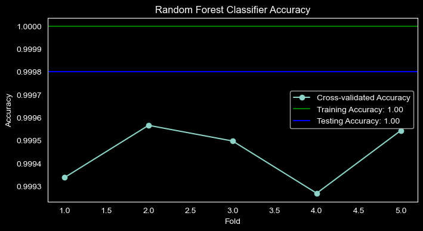

```python
# Cross-validated accuracy scores and mean accuracy for RandomForest
score_rf = [0.99933726, 0.99956579, 0.99949723, 0.99926871, 0.99954294]
mean_accuracy_rf = np.mean(score_rf)

# Training and testing accuracy for RandomForest
training_accuracy_rf = 1.0
testing_accuracy_rf = 0.9997997649414531

# Plotting the accuracies for RandomForest
plt.figure(figsize=(8, 4))
plt.plot(range(1, 6), score_rf, marker='o', linestyle='-', label='Cross-validated Accuracy')
#plt.axhline(y=mean_accuracy_rf, color='r', linestyle='--', label=f'Average CV Accuracy: {mean_accuracy_rf:.2f}')
plt.axhline(y=training_accuracy_rf, color='g', linestyle='-', label=f'Training Accuracy: {training_accuracy_rf:.2f}')
plt.axhline(y=testing_accuracy_rf, color='b', linestyle='-', label=f'Testing Accuracy: {testing_accuracy_rf:.2f}')
plt.title('Random Forest Classifier Accuracy')
plt.xlabel('Fold')
plt.ylabel('Accuracy')
plt.legend(loc='best')
plt.grid(False)
plt.show()
```

### predicting with random Forest Classifier

```python
from sklearn.metrics import confusion_matrix, classification_report

y_pred = rf_clf.predict(x_test_rf)

accuracy = accuracy_score(y_test_rf, y_pred)
print(f"Accuracy: {accuracy}")

#conf_matrix = confusion_matrix(y_test_rf, y_pred)
#print(f"confusion_matrix: {conf_matrix}")
print("confusion matrix:--------------------------")
print(confusion_matrix(y_test_rf, y_pred))

print('classification report:----------------------')
print(classification_report(y_test_rf, y_pred))
```

```
Accuracy: 0.9995086621051099
confusion matrix:--------------------------
[[13635    19     0     1]
 [    0 13780     0     0]
 [    0     0 13799     0]
 [    7     0     0 13711]]
classification report:----------------------
              precision    recall  f1-score   support

           0       1.00      1.00      1.00     13655
           1       1.00      1.00      1.00     13780
           2       1.00      1.00      1.00     13799
           3       1.00      1.00      1.00     13718

    accuracy                           1.00     54952
   macro avg       1.00      1.00      1.00     54952
weighted avg       1.00      1.00      1.00     54952
```

The Random Forest Classifier performed almost perfectly in this test, with an accuracy of 99.95%, meaning it correctly predicted nearly all the examples.

### Saving the Model for deployment using pickle

```python
import pickle

# Save the trained model using pickle
with open('random_forest_model.pkl', 'wb') as model_file:
    pickle.dump(rf_clf, model_file)

print("Model saved successfully as 'random_forest_model.pkl'")
```

```
Model saved successfully as 'random_forest_model.pkl'
```

#### loading the model

```python
import pickle
import numpy as np

# Load the saved RandomForest model
with open('random_forest_model.pkl', 'rb') as model_file:
    model = pickle.load(model_file)

print("Model loaded successfully!")
```

```
Model loaded successfully!
```

#### Testing by Making a prediction

```python
# Define the input data (replace with actual feature values)
input_data = np.array([22.4, 60.5, 1008.7, 5.2, 120.0, 9.1, 0.6, 14.7, 0.9, 55.8, 24.3, 3.1, 1.8, 5.6, 0.7, 1009.8, 13.2, 0.9])

# Reshape the input data to match the model’s expected input format
input_data = input_data.reshape(1, -1)

# Make a prediction
prediction = model.predict(input_data)

# Display the prediction
print(f"Predicted class: {prediction[0]}")
```

```
Predicted class: 2
```

```python
###to test
## to run flask server

#python app.py


## curl -X POST http://127.0.0.1:5000/predict -H "Content-Type: application/json" -d "{\"input\": [15.6, 70.2, 1010.3, 3.5, 80.0, 6.7, 0.4, 10.2, 1.2, 50.3, 22.9, 1.8, 2.4, 4.0, 0.8, 1011.5, 11.6, 0.5]}"

## curl -X POST http://127.0.0.1:5000/predict -H "Content-Type: application/json" -d "{\"input\": [22.4, 60.5, 1008.7, 5.2, 120.0, 9.1, 0.6, 14.7, 0.9, 55.8, 24.3, 3.1, 1.8, 5.6, 0.7, 1009.8, 13.2, 0.9]}"
```

```python
import pandas as pd
import pandas as pd

# Creating a DataFrame with weather categories
data = {'weather': ['rainy', 'sunny', 'cloudy', 'stormy']}

# Assign corresponding numeric values for each weather type
data['classes'] = [0, 1, 2, 4]

# Create the DataFrame
df = pd.DataFrame(data)

# Display the DataFrame
df
```

[output not shown]

### conclusion

#### Achievements in This Weather Classification Use Case

##### Highly Accurate Weather Prediction:

- The Random Forest Classifier achieved a high accuracy of 99.95%, meaning it can predict different weather conditions (rainy, sunny, cloudy, and stormy) with almost perfect precision.

Balanced Data for Better Predictions:

- To handle the imbalance in weather labels (with "rainy" being much more frequent), data resampling techniques like SMOTE were used. This balanced the dataset, allowing the model to perform well on all weather types.

Model Comparison and Validation:

- Multiple models were tested (SVM, Decision Trees, AdaBoost), and Random Forest was chosen as the best performing one after cross-validation, ensuring the most reliable predictions.

Data Visualization Insights:

- Clear visualizations helped understand how environmental factors like wind speed, temperature, and pressure change over time, supporting the weather classification and providing additional insights for stakeholders.

#### we gained several key insights and learning outcomes:

##### Air Temperature, Humidity, and Pressure Patterns:

- - High humidity levels throughout the recorded period suggest a moist environment, possibly due to frequent rain.
  - Air temperature fluctuates regularly, indicating daily or seasonal cycles.
  - Atmospheric pressure remains mostly stable, pointing to fewer extreme weather events like storms.

##### Ozone Levels and Pollutant Impact:

- - Carbon monoxide and nitrogen dioxide have the biggest impact on ozone levels, with carbon monoxide having the strongest influence.
  - Controlling carbon monoxide and nitrogen dioxide emissions is key to managing ozone levels.

##### Ozone Levels Consistency:

- - Ozone levels have stayed stable from 2021 to 2024, mostly between 100 and 200 units.
  - This consistency suggests that pollution sources have not increased or decreased significantly during this time.

##### Pollution Trends Over the Year:

- - Carbon Monoxide (CO) and Nitrogen Dioxide (NO2): Monthly fluctuations without a clear increase or decrease, showing consistent pollution sources like traffic and industry.
  - PM10 (Particulate Matter): Levels vary each month, likely influenced by weather or other environmental factors.
  - PM2.5 (Particulate Matter): Stable and low levels, indicating effective control measures.

##### Seasonal Wind Speed Variation:

- - Wind speeds peak in February and September, with stronger winds during these months.
  - Wind speeds drop notably in October and December, showing the seasonal changes in wind patterns.

##### Vapour Pressure and Humidity Relationship:

- - Higher humidity is often linked with higher vapour pressure.
  - When humidity is above 60%, vapour pressure values tend to be higher, while lower humidity corresponds with lower vapour pressure.

#### At broad Level

In this project, I developed a model that can predict weather conditions using key environmental data such as temperature, humidity, air pressure, and pollution levels. The model was tested and showed strong accuracy in its predictions, meaning it can be trusted to provide reliable insights about upcoming weather.

I saved the model so it can be easily reused in future applications without needing to retrain it. I also tested it with different sets of data to ensure it works as expected.

This solution can help organizations in industries like agriculture, construction, and event planning, where weather conditions are important for making decisions. By accurately predicting weather conditions, businesses can plan more efficiently, avoid risks, and make better decisions. This model is ready to be integrated into systems that help make informed decisions, and it can be further improved as more data becomes available.

#### References

[2] Victorian 'Crash-Stat's dataset https://discover.data.vic.gov.au/dataset/crash-stats-data-extract/resource/392b88c0-f010-491f-ac92-531c293de2e9

[8] Creating point plot group layers with folium https://towardsdatascience.com/creating-an-interactive-map-of-wildfire-data-using-folium-in-pythoiveTimeSeries.html

[8] Machine learning tutorial https://www.youtube.com/watch?v=7eh4d6sabA0&t=6s

[8] Machine learning reading: https://www.coursera.org/articles/what-is-machine-learning?msockid=345dd51d5bb367590de6c1655a6666f1

[8] Intelligence Analysis skill : https://www.youtube.com/watch?v=iuU_GI5WMpY

[8] Australia Bureau mete0rology : http://www.bom.gov.au/vic/forecasts/melbourne.shtml

[8] Atmosphere Earth DAta : https://www.earthdata.nasa.gov/topics/atmosphere